# a00354741_lr

IA4000-Sistemas Inteligentes – Examen 3 - 8 May 2018

Matrícula: **A00354741** Nombre: **Luis Antonio Reynoso Salcedo**

READ CAREFULLY:

**1** The exam MUST be solved in jupyter notebook using Python kernel

**2** Any plot will be programed with instructions of Matplotlib

**3** Your have to write / answer / plot immediately below in every Section and Sub-section where it is asked.

**4** Points will be deducted if:

- The program fails (excused if it fails by a library problem)
- Do not use only matplotlib
- Missing to include x label AND y label AND title plot IN EVERY PLOT
- Do not do what is asked

**5** It is allowed to import any required library to complete what is asked But, it is not allowed to delete/replace any code already including this document

**6** Your will submit your Jupyter Notebook file **matricula_LR.ipynb** and **matricula_LR.html** to blackboard

- Missing any of both files will deduct points
- you can submit several times your files, only the last one will be taken to grade

### Do not remove instructions, sections, subsections.

### Respect the order of the exam.

# Exam 3 - PART 1 - Linear Regression

This is an Ecommerce company based in New York City that sells clothing online but they also have in-store style and clothing advice sessions. Customers come in to the store, have sessions/meetings with a personal stylist, then they can go home and order either on a mobile app or website for the clothes they want.

The company is trying to decide whether to focus their efforts on their mobile app experience or their website. They've hired you on contract to help them figure it out! Let's get started!

## Imports

**Import pandas, numpy, matplotlib,and seaborn. Then set %matplotlib inline (You'll import sklearn as you need it.)**

```python
import pandas as pd
import numpy as np
import matplotlib.pyplot as plt
import seaborn as sns
%matplotlib inline
```

## Get the Data

We'll work with the Ecommerce Customers csv file from the company. It has Customer info, suchas Email, Address, and their color Avatar. Then it also has numerical value columns:

- Avg. Session Length: Average session of in-store style advice sessions.
- Time on App: Average time spent on App in minutes
- Time on Website: Average time spent on Website in minutes
- Length of Membership: How many years the customer has been a member.

**Read in the Ecommerce Customers csv file as a DataFrame called customers.**

```python
customers = pd.read_csv("EcommerceCustomers.csv")
```

**Check the head of customers, and check out its info() and describe() methods.**

```python
customers.tail()
```

|  | Email | Address | Avatar | Avg. Session Length | Time on App | Time on Website | Length of Membership | Yearly Amount Spent |
| --- | --- | --- | --- | --- | --- | --- | --- | --- |
| 495 | lewisjessica@craig-evans.com | 4483 Jones Motorway Suite 872\nLake Jamiefurt,... | Tan | 33.237660 | 13.566160 | 36.417985 | 3.746573 | 573.847438 |
| 496 | katrina56@gmail.com | 172 Owen Divide Suite 497\nWest Richard, CA 19320 | PaleVioletRed | 34.702529 | 11.695736 | 37.190268 | 3.576526 | 529.049004 |
| 497 | dale88@hotmail.com | 0787 Andrews Ranch Apt. 633\nSouth Chadburgh, ... | Cornsilk | 32.646777 | 11.499409 | 38.332576 | 4.958264 | 551.620145 |
| 498 | cwilson@hotmail.com | 680 Jennifer Lodge Apt. 808\nBrendachester, TX... | Teal | 33.322501 | 12.391423 | 36.840086 | 2.336485 | 456.469510 |
| 499 | hannahwilson@davidson.com | 49791 Rachel Heights Apt. 898\nEast Drewboroug... | DarkMagenta | 33.715981 | 12.418808 | 35.771016 | 2.735160 | 497.778642 |

```python
customers.describe()
```

|  | Avg. Session Length | Time on App | Time on Website | Length of Membership | Yearly Amount Spent |
| --- | --- | --- | --- | --- | --- |
| count | 500.000000 | 500.000000 | 500.000000 | 500.000000 | 500.000000 |
| mean | 33.053194 | 12.052488 | 37.060445 | 3.533462 | 499.314038 |
| std | 0.992563 | 0.994216 | 1.010489 | 0.999278 | 79.314782 |
| min | 29.532429 | 8.508152 | 33.913847 | 0.269901 | 256.670582 |
| 25% | 32.341822 | 11.388153 | 36.349257 | 2.930450 | 445.038277 |
| 50% | 33.082008 | 11.983231 | 37.069367 | 3.533975 | 498.887875 |
| 75% | 33.711985 | 12.753850 | 37.716432 | 4.126502 | 549.313828 |
| max | 36.139662 | 15.126994 | 40.005182 | 6.922689 | 765.518462 |

```python
customers.info()
```

```
<class 'pandas.core.frame.DataFrame'>
RangeIndex: 500 entries, 0 to 499
Data columns (total 8 columns):
Email                   500 non-null object
Address                 500 non-null object
Avatar                  500 non-null object
Avg. Session Length     500 non-null float64
Time on App             500 non-null float64
Time on Website         500 non-null float64
Length of Membership    500 non-null float64
Yearly Amount Spent     500 non-null float64
dtypes: float64(5), object(3)
memory usage: 31.3+ KB
```

## Exploratory Data Analysis

# 1 )

**Construct a scatter plot of Yearly Amount Spent vs each numeric variable:**  
**USE ONLY MATPLOTLIB**

- Avg. Session Length: Average session of in-store style advice sessions.
- Time on App: Average time spent on App in minutes
- Time on Website: Average time spent on Website in minutes
- Length of Membership: How many years the customer has been a member.

### Example code to construct a scattered plot using matplotlib

plt.figure(num=None, dpi=100, facecolor='w', edgecolor='black')  
plt.scatter(x='Time on Website', y='Yearly Amount Spent', data=customers, s=20, c="darkgreen");  
plt.xlabel("Time on Website")  
plt.ylabel("Yearly Amount Spent")  
plt.title('Yearly amount spent by time on website', fontsize=12)  
plt.show()

Do not forget to include **x, y** and **title** of the plot labels, otherwise points will be deducted

**a) Avg. Session Length**

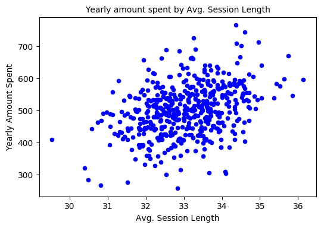

```python
plt.figure(num=None, dpi=100, facecolor='w', edgecolor='black')
y = customers['Yearly Amount Spent']
X = customers['Avg. Session Length']
plt.scatter(X, y, s=20, c="blue")
plt.xlabel("Avg. Session Length")
plt.ylabel("Yearly Amount Spent")
plt.title('Yearly amount spent by Avg. Session Length', fontsize=10)
plt.show()
```

**b) Time on App**

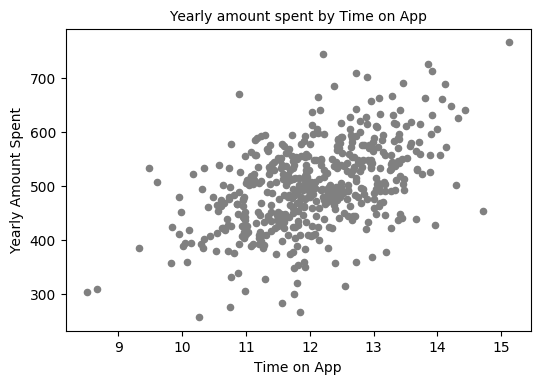

```python
plt.figure(num=None, dpi=100, facecolor='w', edgecolor='black')
y = customers['Yearly Amount Spent']
X = customers['Time on App']
plt.scatter(X, y, s=20, c="grey")
plt.xlabel("Time on App")
plt.ylabel("Yearly Amount Spent")
plt.title('Yearly amount spent by Time on App', fontsize=10)
plt.show()
```

**c) Time on Website**

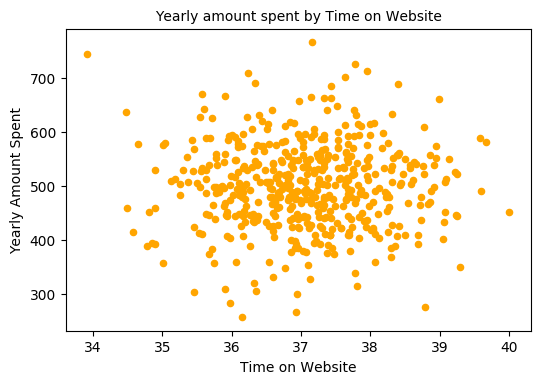

```python
plt.figure(num=None, dpi=100, facecolor='w', edgecolor='black')
y = customers['Yearly Amount Spent']
X = customers['Time on Website']
plt.scatter(X, y, s=20, c="orange")
plt.xlabel("Time on Website")
plt.ylabel("Yearly Amount Spent")
plt.title('Yearly amount spent by Time on Website', fontsize=10)
plt.show()
```

**d) Length of Membership**

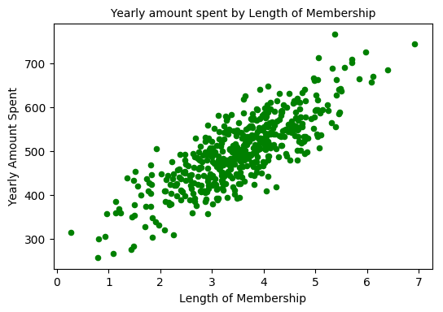

```python
plt.figure(num=None, dpi=100, facecolor='w', edgecolor='black')
y = customers['Yearly Amount Spent']
X = customers['Length of Membership']
plt.scatter(X, y, s=20, c="green")
plt.xlabel("Length of Membership")
plt.ylabel("Yearly Amount Spent")
plt.title('Yearly amount spent by Length of Membership', fontsize=10)
plt.show()
```

## Simple Linear Regression Modelling

# 2 )

**Construct one linear regression model of the dependent variable "Yearly Amount Spent" by each independent varialble**

- Construct the Simple linear regression model using the 100% of the data points
- Show the summary of the model
- **In two rows maximum** explain the significance of the independent variable (**mention its p-value and R-squared**
- Plot the linear regression model together the data points, **line color=red**

Do not forget to include **x, y** and **title** of the plot labels, otherwise points will be deducted

**a) Avg. Session Length**

[figure not shown]

```python
plt.figure(num=None, dpi=100, facecolor='w', edgecolor='black')
X = customers['Avg. Session Length']
y = customers['Yearly Amount Spent']
plt.scatter(X, y, s=20, c="blue");
fit = np.polyfit(x, y, deg=1)
plt.plot(x, fit[0] * x + fit[1], color='red', label='Linear Regression')
plt.xlabel("Avg. Session Length")
plt.ylabel("Yearly Amount Spent")
plt.title('Yearly amount spent by Avg. Session Length', fontsize=10)
plt.show()
```

**b) Time on App**

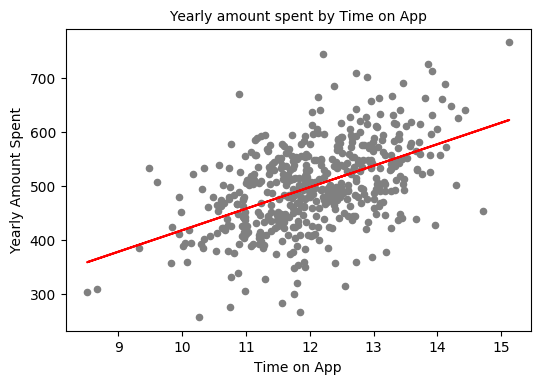

```python
plt.figure(num=None, dpi=100, facecolor='w', edgecolor='black')
X = customers['Time on App']
y = customers['Yearly Amount Spent']
plt.scatter(x, y, s=20, c="grey");
fit = np.polyfit(x, y, deg=1)
plt.plot(x, fit[0] * x + fit[1], color='red', label='Linear Regression')
plt.xlabel("Time on App")
plt.ylabel("Yearly Amount Spent")
plt.title('Yearly amount spent by Time on App', fontsize=10)
plt.show()
```

**c) Time on Website**

[figure not shown]

```python
plt.figure(num=None, dpi=100, facecolor='w', edgecolor='black')
X = customers['Time on Website']
y = customers['Yearly Amount Spent']
plt.scatter(x, y, s=20, c="orange");
fit = np.polyfit(x, y, deg=1)
plt.plot(x, fit[0] * x + fit[1], color='red', label='Linear Regression')
plt.xlabel("Time on Website")
plt.ylabel("Yearly Amount Spent")
plt.title('Yearly amount spent by Time on Website', fontsize=10)
plt.show()
```

**d) Length of Membership**

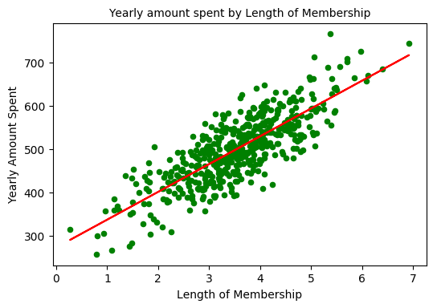

```python
plt.figure(num=None, dpi=100, facecolor='w', edgecolor='black')
X = customers['Length of Membership']
y = customers['Yearly Amount Spent']
plt.scatter(x, y, s=20, c="green");
fit = np.polyfit(x, y, deg=1)
plt.plot(x, fit[0] * x + fit[1], color='red', label='Linear Regression')
plt.xlabel("Length of Membership")
plt.ylabel("Yearly Amount Spent")
plt.title('Yearly amount spent by Length of Membership', fontsize=10)
plt.show()
```

## Multiple Linear Regression Modelling

# 3 )

**Construct one multiple linear regression model of the dependent variable "Yearly Amount Spent" by all the independent numeric varialble:** Avg. Session Length, Time on App, Time on Website, and Length of Membership.

- Construct a Multiple linear regression model using the 100% of the data points
- Show the summary of the model
- Explain the significance of the independent variables based on **their p-value and their R-squared**

```
Coefficients:
 [25.98154972 38.59015875  0.19040528 61.27909654]
```

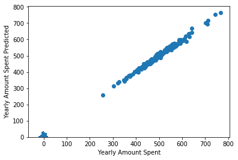

```
Model intercept:     -1051.5942553006246
Model slope:         25.734271084705064
Model slope:         38.709153810834366
```

```
0.9843155370226726
```

```python
#Multiple linear regression
from sklearn.linear_model import LinearRegression
from sklearn import linear_model
from sklearn.model_selection import train_test_split
X_train, X_test, y_train, y_test = train_test_split(X, y, test_size=0.3, random_state=101)
y = customers['Yearly Amount Spent']
X = customers[['Avg. Session Length', 'Time on App','Time on Website', 'Length of Membership']]
lm = LinearRegression()
lm.fit(X_train,y_train)
# The coefficients
print('Coefficients: \n', lm.coef_)
predictions = lm.predict(X_test)
lm.score(X,y)
plt.scatter(y_test, predictions)
plt.xlabel('Yearly Amount Spent')
plt.ylabel('Yearly Amount Spent Predicted')
plt.hist((y_test-predictions))
plt.show()
modelM = linear_model.LinearRegression()
modelM.fit(X,y)
print("Model intercept:    ",modelM.intercept_)
print("Model slope:        ",modelM.coef_[0])
print("Model slope:        ",modelM.coef_[1])
#r-square
modelM.score(X,y)
```

## Plotting the analysis of residuals from the multiple linear regression model from 3)

# 4 )

- Add two new columns to the data set:
  - FittedModel
  - Residuals
- Prove the analysis of residuals by plot:
  - In a ( 2 x 2 ) quadrant, plot the Residuals vs each independent variable
    - (e.g., in place (1,1) Residuals vs Avg. Session Length
    - (e.g., in place (1,2) Residuals vs Time on App
    - (e.g., in place (2,1) Residuals vs Time on Website
    - (e.g., in place (2,2) Resicuals vs Length of Membership
  - In a ( 1 x 2 ) quadrant, plot the Residuals vs observed and fitted Yearly Amount Spent
    - (e.g., in place (1,1) Residuals vs observed Yearly Amount Spent (y)
    - (e.g., in place (1,2) Residuals vs fitted Yearly Amount Spent (y^)
  - In a ( 1 x 1 ) quadrant, plot the Normal probability plot of Residuals

Do not forget to include **x, y** and **title** of the plot labels, otherwise points will be deducted

```
Text(0,0.5,'Residual')
```

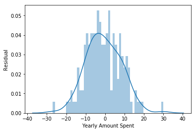

```python
#residual from model
#plt.hist((y_test-predictions), bins=25, histtype='barstacked', density=True, facecolor='g', alpha=0.75)
sns.distplot((y_test-predictions),bins=50);
plt.xlabel('Yearly Amount Spent')
plt.title('')
plt.ylabel('Residual')
```

## Based on your work so far, what is the most correlated independent variable to the Yearly Amount Spent

# 5 )

**Write your response HERE:**

```python
coeffecients = pd.DataFrame(lm.coef_,X.columns)
coeffecients.columns = ['Coeffecient']
coeffecients
```

|  | Coeffecient |
| --- | --- |
| Avg. Session Length | 25.981550 |
| Time on App | 38.590159 |
| Time on Website | 0.190405 |
| Length of Membership | 61.279097 |

## Using the model - This section for learning

# 6)

**You will be given a serie of instruccions on the next few lines related to:**

- How to split the data set randomly,
- Construct the model
- Train the model and
- Then test the model

```python
y = customers['Yearly Amount Spent']
```

```python
X = customers[['Avg. Session Length', 'Time on App','Time on Website', 'Length of Membership']]
```

**Use model_selection.train_test_split from sklearn to split the data into training and testing sets. Set test_size=0.3 and random_state=101**

```python
from sklearn.model_selection import train_test_split
```

```python
seed=101
X_train, X_test, y_train, y_test = train_test_split(X, y, test_size=0.3, random_state=seed)
```

### Training the Model

Now its time to train our model on our training data!

**Import LinearRegression from sklearn.linear_model :**

```python
from sklearn.linear_model import LinearRegression
```

**Create an instance of a LinearRegression() model named lm :**

```python
lm = LinearRegression()
```

**Train/fit lm on the training data :**

```python
lm.fit(X_train,y_train)
```

```
LinearRegression(copy_X=True, fit_intercept=True, n_jobs=1, normalize=False)
```

### Predicting Test Data

Now that we have fit our model, let's evaluate its performance by predicting off the test values!

**Use lm.predict() to predict off the X_test set of the data :**

```python
predictions = lm.predict( X_test)
```

**Construct a data frame from "y_test" and "predictions" :**

```python
# convert observed y to data frame
df1 = y_test.to_frame()
df1=df1.reset_index(drop=True)
# convert predictions to data frame
df2 = pd.DataFrame(predictions)
df2.columns = ['predictions']
# concatenate in one data frame observed, predictions
y_tested_new = pd.concat([df1, df2], axis=1)
```

**Add the Residuals to the data frame :**

```python
# compute the residuals from y - y^
residuals = [y_tested_new.at[i,'Yearly Amount Spent']-y_tested_new.at[i,'predictions'] for i in range(len(predictions))]
# convert residuals to data frame
df3 = pd.DataFrame(residuals)
df3.columns = ['residuals']
# concatenate in one data frame observed, predictions, residuals
y_tested_new = pd.concat([y_tested_new, df3], axis=1)
```

```python
y_tested_new.head()
```

|  | Yearly Amount Spent | predictions | residuals |
| --- | --- | --- | --- |
| 0 | 452.315675 | 456.441861 | -4.126186 |
| 1 | 401.033135 | 402.720053 | -1.686918 |
| 2 | 410.069611 | 409.253154 | 0.816457 |
| 3 | 599.406092 | 591.431034 | 7.975058 |
| 4 | 586.155870 | 590.014373 | -3.858503 |

### Evaluating the Model

**Calculate the following:**

**MAE :** The Mean Absolute Error measures how far estimates or forecasts differ from actual values.

**MSE :** The Mean Squared Error tells you how close a regression line is to a set of points. It does this by taking the distances from the points to the regression line (these distances are the “errors”) and squaring them. The smaller the means squared error, the closer you are to finding the line of best fit.

**RMSE:** The Root Mean Squared Error represents the sample standard deviation of the differences between predicted values and observed values.

```python
MAE=0.0
MSE=0.0
RMSE=0.0
for i in range(len(y_tested_new)):
    MAE = MAE + abs(y_tested_new.at[i,'residuals'])
    MSE = MSE + pow(y_tested_new.at[i,'residuals'], 2)
# divide by the total number of tested instances
MAE = MAE / len(y_tested_new)
MSE = MSE / len(y_tested_new)
RMSE = pow(MSE, 0.5)
print (MAE)
print (MSE)
print (RMSE)
```

```
7.22814865343
79.813051651
8.93381506698
```

**Keep the results in a data frame for future uses:**

```python
evalCriteria = pd.DataFrame(columns=["MAE", "MSE", "RMSE"])
evalCriteria = evalCriteria.append({
     "MAE": MAE,
     "MSE": MSE,
     "RMSE": RMSE
      }, ignore_index=True)
evalCriteria
```

|  | MAE | MSE | RMSE |
| --- | --- | --- | --- |
| 0 | 7.228149 | 79.813052 | 8.933815 |

## Using the model - This section for applying 6) many times

# 7)

**You will copy the necessary instructions from 6) and you will:**

Do not forget to include **x, y** and **title** of the plot labels, otherwise points will be deducted

**All your work HERE:** You can add as many rows as necessary.

```python
y = customers['Yearly Amount Spent']
X = customers[['Avg. Session Length', 'Time on App','Time on Website', 'Length of Membership']]
from sklearn.model_selection import train_test_split
from sklearn.linear_model import LinearRegression

num_rep = 0
while num_rep < 18:
    print('Iteration # : ',num_rep)
    num_rep += 1

seed=101
X_train, X_test, y_train, y_test = train_test_split(X, y, test_size=0.3, random_state=seed)

lm = LinearRegression()
lm.fit(X_train,y_train)
predictions = lm.predict( X_test)
# convert observed y to data frame
df1 = y_test.to_frame()
df1=df1.reset_index(drop=True)
# convert predictions to data frame
df2 = pd.DataFrame(predictions)
df2.columns = ['predictions']
# concatenate in one data frame observed, predictions
y_tested_new = pd.concat([df1, df2], axis=1)
# compute the residuals from y - y^
residuals = [y_tested_new.at[i,'Yearly Amount Spent']-y_tested_new.at[i,'predictions'] for i in range(len(predictions))]
# convert residuals to data frame
df3 = pd.DataFrame(residuals)
df3.columns = ['residuals']
# concatenate in one data frame observed, predictions, residuals
y_tested_new = pd.concat([y_tested_new, df3], axis=1)
y_tested_new.head()
MAE=0.0
MSE=0.0
RMSE=0.0
for i in range(len(y_tested_new)):
    MAE = MAE + abs(y_tested_new.at[i,'residuals'])
    MSE = MSE + pow(y_tested_new.at[i,'residuals'], 2)
# divide by the total number of tested instances
MAE = MAE / len(y_tested_new)
MSE = MSE / len(y_tested_new)
RMSE = pow(MSE, 0.5)
print (MAE)
print (MSE)
print (RMSE)
evalCriteria = pd.DataFrame(columns=["MAE", "MSE", "RMSE"])
evalCriteria = evalCriteria.append({
     "MAE": MAE,
     "MSE": MSE,
     "RMSE": RMSE
      }, ignore_index=True)
evalCriteria
```

[output not shown]

|  | MAE | MSE | RMSE |
| --- | --- | --- | --- |
| 0 | 7.228149 | 79.813052 | 8.933815 |